# Agentes Inteligentes

Universidad Austral

Claude Desktop - Chat

Autor: Paulo Veiga y Marco Sánchez Sorondo  
Última modificación: Julio 2026

[figure not shown]

01Introducción 02Context augmentation 03Web search 04Connectors 05Claude in Chrome 06Schedule 07La mission

01

Introducción

Introducción

## El problema: horas que se van en trabajo manual

### Tareas repetitivas

El trabajo de oficina está lleno de tareas **repetitivas**: armar el mismo reporte, pasar datos de un lado a otro, resumir el inbox, consolidar planillas.

### Información dispersa

La información vive **dispersa**: mails, planillas, PDFs, sistemas internos. Analizarla junta cuesta horas.

### Había que saber programar

Hasta ahora, automatizar eso pedía **saber programar**, o resignarse a hacerlo a mano.

Introducción

## Cómo lo vamos a atacar

### Con agentes de IA

No solo responden, **ejecutan trabajo**, automatizan tareas y analizan datos.

### La herramienta

**Claude Desktop** y sus dos caras, **Chat y Cowork**.

### El camino

Esta clase extiende el chat que ya usan (búsqueda, Connectors, Schedule); la segunda baja a Cowork, donde se delega trabajo completo.

Introducción

## Quién es Anthropic

### Qué es

Empresa de IA fundada en 2021 en San Francisco por ex-OpenAI, entre ellos los hermanos Dario y Daniela Amodei. Creadora de Claude.

### Por qué existe

Su apuesta es que la IA va a ser transformacional y que hay que desarrollarla con foco en seguridad. El *safety-first* es su diferencial de marca frente a otros labs.

### Cómo se estructura

Public Benefit Corporation, con mandato de balancear ganancias y misión. Entre sus inversores están Google y Amazon.

### Qué la distingue

Constitutional AI, foco en interpretabilidad y alineación, y políticas de uso responsable (Acceptable Use Policy, Responsible Scaling Policy).

Introducción

## Las cuatro herramientas de Claude

### Claude Chat/Web

claude.ai: el asistente conversacional de uso diario, en el navegador. *El tema de esta clase.*

### Claude Code

CLI agéntico en la terminal, para developers. Coding de punta a punta.

### Claude Cowork

Claude instalado en la computadora, para quien no programa. Trabajo multipaso sobre carpetas y archivos reales. *El foco de la segunda clase.*

### Claude Design

Prototipos, mockups y slides a partir de una idea, para quien no tiene formación de diseño (founders, product managers).

[figure not shown]

Introducción

## Claude Desktop Chat

### El mismo producto

Mismo modelo, misma cuenta y la conversación sincronizada entre claude.ai y la app de escritorio. Cambia el empaquetado.

### Las diferencias aparecen en la periferia

No en la pestaña Chat: lo que la app de escritorio alcanza en la computadora y la pestaña Cowork que trae al lado.

### El foco de esta clase

Los aspectos avanzados del chat.

*El core es el mismo, así que todo lo que se ve acá aplica también a Cowork.*

Introducción

## El chat en Claude Desktop

La pantalla sobre la que se trabaja el resto de la clase.

[figure not shown]

01Introducción 02Context augmentation 03Web search 04Connectors 05Claude in Chrome 06Schedule 07La mission

02

Context augmentation

Context augmentation

## El chat responde de memoria

De fábrica el chat responde de su **memoria de entrenamiento**: una foto que llega hasta la **fecha de entrenamiento**. No busca información nueva.

### Información vieja

Lo posterior al corte no existe.

### Alucinación

Inventa con confianza.

### In-context learning

El modelo adapta su comportamiento con lo que ve en el prompt, sin que se actualicen sus pesos ni se lo reentrene.

Enriquecer ese contexto es la única palanca disponible.

[figure not shown]

Context augmentation

## Dos formas de enriquecer el modelo

El contexto es la única palanca, y hay dos maneras de llenarlo. Las dos recorren el resto de la clase.

### Buscar en la web

El chat consulta información actual y cita sus fuentes. Es la más universal y ya viene integrada en casi todos los chats.

### Conectar el chat a los sistemas del usuario

Mail, calendario, documentos, sistemas internos. Además de traer información, ejecuta acciones.

01Introducción 02Context augmentation 03Web search 04Connectors 05Claude in Chrome 06Schedule 07La mission

03

Web search

Web search

## La misma pregunta, dos modos de responder

**Regla**: **Si la respuesta pudo cambiar desde el entrenamiento, la búsqueda es obligatoria.** Precios, noticias, versiones, papers, normativa.

[figure not shown]

Web search

## La búsqueda en pantalla

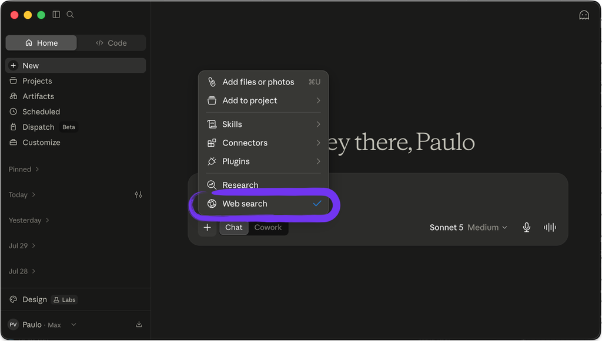

01Introducción 02Context augmentation 03Web search 04Connectors 05Claude in Chrome 06Schedule 07La mission

04

Connectors

Connectors

## Qué es un Connector

- **Connector**: Extensión que conecta el chat a un sistema externo: mail, calendario, documentos.
- Vale igual en ChatGPT, Gemini y Claude.
- Se activa a través de la biblioteca de Connectors. Muchos requieren autenticación.

[figure not shown]

Connectors

## Un Connector deja de ser pasivo

Además de traer info, un Connector expone **acciones**: la IA **hace**.

### Verificado de primera mano

**Dejar redactado un mail** (borrador en Gmail) y **agendar una reunión** (evento en el calendario).

### Capacidad del ecosistema

Abrir un ticket (Jira, ServiceNow) o mandar un mensaje (Slack), sin Connector puntual probado en clase.

Cuidado con las autorizaciones y los permisos. **Un mail enviado sin revisión humana puede generar muchos problemas.**

[figure not shown]

Connectors

## Out of the box y externos

Los Connectors se dividen en dos familias, según quién los prepara: los que vienen listos con el producto y los que conecta el equipo.

Out of the boxExternos

Curación**Curados por Anthropic**: entran al directorio oficial después de pasar por su revisión.La curación no existe: Anthropic no verifica esos servicios.

Cómo se conectanVienen listos con el producto.Toda la familia externa se conecta por el **protocolo MCP**.

**De ahí el criterio de confianza**: Autorizar un Connector externo le da acceso a los datos del usuario, así que conviene reservarlo para servicios confiables.

[figure not shown]

Connectors

## El directorio de Connectors

- El **directorio oficial de Claude** lista los Connectors listos para usar, incluidos proveedores de datos del sector, por ejemplo un proveedor de noticias financieras.

[figure not shown]

Connectors

## Buscar, conectar y autorizar

### Flujo básico

**Buscar el servicio, conectar y autorizar**. Como conectar Gmail a una app nueva.

### Ejemplos guía

**Mail y calendario**. "¿Qué mails me perdí ayer? ¿Qué tengo esta semana?"

[figure not shown]

Connectors

## External connectors: todo pasa por MCP

### Connectors externos

Los que una empresa conecta contra sus propios sistemas o los de un tercero, fuera del catálogo listo para usar.

### MCP

Todos se conectan por **MCP** (Model Context Protocol), el estándar que traduce el pedido del usuario en llamadas al servicio conectado.

### Ejemplo

El usuario pide "los pedidos abiertos del cliente X" y el Connector consulta el ERP de la empresa y devuelve la respuesta al chat.

[figure not shown]

Connectors

## Agregar un external connector

- Se agrega desde la misma biblioteca de Connectors, con la opción de conector propio.
- Lo que hay que tener a mano: la **URL del servidor MCP** y, si el servicio lo pide, sus credenciales.
- Quien monta el servidor es el equipo técnico. Quien lo agrega y lo usa, cualquiera.

[figure not shown]

Connectors

## Dónde buscar servidores MCP publicados

FuenteQué encontrás

github.com/modelcontextprotocol/serversRepo de referencia mantenido por la comunidad y Anthropic

PulseMCP (pulsemcp.com)Directorio curado, marca cuáles son oficiales del proveedor

Smithery (smithery.ai)Marketplace de servidores MCP, instalación asistida

Glama (glama.ai/mcp/servers)Directorio con ranking y metadata de cada servidor

mcp.soListado comunitario amplio

01Introducción 02Context augmentation 03Web search 04Connectors 05Claude in Chrome 06Schedule 07La mission

05

Claude in Chrome

Claude in Chrome

## Que es Claude in Chrome ?

**Claude in Chrome**: una extensión de Chrome. Claude abre un panel al costado de la página y ve lo mismo que ve el usuario.

### Sesión ya iniciada

Trabaja dentro de la sesión del navegador ya iniciada, en los sitios donde el usuario ya está identificado.

### Qué hace ahí

Navega, hace clic, completa formularios y encadena varios pasos entre pestañas.

### Conocimiento incorporado

Trae conocimiento incorporado de **Slack, Google Calendar, Gmail y Google Docs**, así que responde a un pedido en lenguaje corriente ("agendá una reunión").

[figure not shown]

Claude in Chrome

## Cuándo sirve Claude in Chrome

### Cargar datos en un sistema web

Pasar al CRM o al ERP lo que llegó por mail o en una planilla, campo por campo.

### Comparar proveedores

Precios y condiciones abiertos en varias pestañas, consolidados en un cuadro.

### Coordinar agenda y correo

Leer el hilo, agendar la reunión en Google Calendar y dejar la respuesta escrita.

### Relevar un portal que no exporta

Listados de precios, licitaciones o estados de pedido, volcados a una tabla.

[figure not shown]

01Introducción 02Context augmentation 03Web search 04Connectors 05Claude in Chrome 06Schedule 07La mission

06

Schedule

Schedule

## Describir una vez, que corra sola

**Schedule**: Describir un trabajo una vez y fijarle una cadencia; el prompt se ejecuta solo, sin volver a pedirlo.

### El ejemplo

*"todos los días 8:00, resumí mi inbox, lo urgente arriba."*

### Dónde existe

[figure not shown]

Schedule

## Dónde vive el Schedule

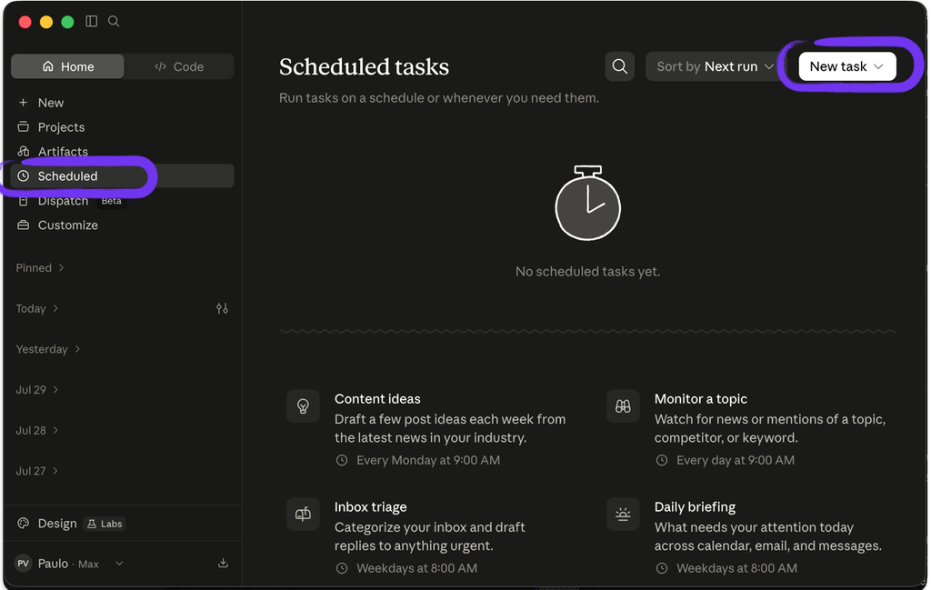

Schedule

## ¿Dónde corre? Local o nube

Antes de confiarle algo a un Schedule: **saber dónde corre**.

- Los Schedule que usan **archivos o apps locales** corren local **siempre**, incluso con la ejecución en la nube disponible.

[figure not shown]

Conclusions

## El lunes: qué hacer con esto

### La idea que queda

**El chat consulta información actual y ejecuta acciones sobre el mail y la agenda.** Alcanza con configurar la cuenta que ya está en uso, sin instalar nada ni escribir código.

### Para esta semana

Activar la búsqueda, conectar el mail y la agenda, y dejar programado un trabajo recurrente.

### Aprobación humana

**Ninguna acción que importe se ejecuta sin aprobación humana.** El contenido que la IA lee puede traer instrucciones que nadie pidió, y Anthropic lo documenta como riesgo abierto.

### La segunda clase

Retoma este chat extendido y sigue en **Claude Cowork**, donde el agente trabaja sobre carpetas y archivos del usuario.

01Introducción 02Context augmentation 03Web search 04Connectors 05Claude in Chrome 06Schedule 07La mission

07

La mission

La mission

## La misión, parte 1: Faro en el chat

Ahora vamos a la misión.